# Exercise_ggplot

dzt

4/20/2021

## 1. Load package ggplot and the dataset “movies” from the package, and have a look at the dataset

```r
library(ggplot2)
library(ggplot2movies)
library(dplyr)
glimpse(movies)
```

```
## Rows: 58,788
## Columns: 24
## $ title       <chr> "$", "$1000 a Touchdown", "$21 a Day Once a Month", "$40,0…
## $ year        <int> 1971, 1939, 1941, 1996, 1975, 2000, 2002, 2002, 1987, 1917…
## $ length      <int> 121, 71, 7, 70, 71, 91, 93, 25, 97, 61, 99, 96, 10, 10, 10…
## $ budget      <int> NA, NA, NA, NA, NA, NA, NA, NA, NA, NA, NA, NA, NA, NA, NA…
## $ rating      <dbl> 6.4, 6.0, 8.2, 8.2, 3.4, 4.3, 5.3, 6.7, 6.6, 6.0, 5.4, 5.9…
## $ votes       <int> 348, 20, 5, 6, 17, 45, 200, 24, 18, 51, 23, 53, 44, 11, 12…
## $ r1          <dbl> 4.5, 0.0, 0.0, 14.5, 24.5, 4.5, 4.5, 4.5, 4.5, 4.5, 4.5, 4…
## $ r2          <dbl> 4.5, 14.5, 0.0, 0.0, 4.5, 4.5, 0.0, 4.5, 4.5, 0.0, 0.0, 0.…
## $ r3          <dbl> 4.5, 4.5, 0.0, 0.0, 0.0, 4.5, 4.5, 4.5, 4.5, 4.5, 4.5, 4.5…
## $ r4          <dbl> 4.5, 24.5, 0.0, 0.0, 14.5, 14.5, 4.5, 4.5, 0.0, 4.5, 14.5,…
## $ r5          <dbl> 14.5, 14.5, 0.0, 0.0, 14.5, 14.5, 24.5, 4.5, 0.0, 4.5, 24.…
## $ r6          <dbl> 24.5, 14.5, 24.5, 0.0, 4.5, 14.5, 24.5, 14.5, 0.0, 44.5, 4…
## $ r7          <dbl> 24.5, 14.5, 0.0, 0.0, 0.0, 4.5, 14.5, 14.5, 34.5, 14.5, 24…
## $ r8          <dbl> 14.5, 4.5, 44.5, 0.0, 0.0, 4.5, 4.5, 14.5, 14.5, 4.5, 4.5,…
## $ r9          <dbl> 4.5, 4.5, 24.5, 34.5, 0.0, 14.5, 4.5, 4.5, 4.5, 4.5, 14.5,…
## $ r10         <dbl> 4.5, 14.5, 24.5, 45.5, 24.5, 14.5, 14.5, 14.5, 24.5, 4.5, …
## $ mpaa        <chr> "", "", "", "", "", "", "R", "", "", "", "", "", "", "", "…
## $ Action      <int> 0, 0, 0, 0, 0, 0, 1, 0, 0, 0, 0, 0, 0, 0, 1, 1, 0, 0, 1, 0…
## $ Animation   <int> 0, 0, 1, 0, 0, 0, 0, 0, 0, 0, 0, 0, 0, 0, 0, 0, 0, 0, 0, 1…
## $ Comedy      <int> 1, 1, 0, 1, 0, 0, 0, 0, 0, 0, 0, 0, 1, 0, 1, 1, 0, 0, 1, 1…
## $ Drama       <int> 1, 0, 0, 0, 0, 1, 1, 0, 1, 0, 1, 0, 0, 0, 0, 0, 1, 0, 0, 0…
## $ Documentary <int> 0, 0, 0, 0, 0, 0, 0, 1, 0, 0, 0, 0, 0, 0, 0, 0, 0, 1, 0, 0…
## $ Romance     <int> 0, 0, 0, 0, 0, 0, 0, 0, 0, 0, 0, 0, 0, 0, 0, 0, 0, 0, 0, 0…
## $ Short       <int> 0, 0, 1, 0, 0, 0, 0, 1, 0, 0, 0, 0, 1, 1, 0, 0, 0, 1, 0, 1…
```

Data description:

title. Title of the movie.

year. Year of release.

budget. Total budget (if known) in US dollars

length. Length in minutes.

rating. Average IMDB user rating.

votes. Number of IMDB users who rated this movie.

r1-10. Multiplying by ten gives percentile (to nearest 10%) of users who rated this movie a 1.

mpaa. MPAA rating.

action, animation, comedy, drama, documentary, romance, short. Binary variables representing if movie was classified as belonging to that genre.

## 2. Draw a rating distribution in histogram

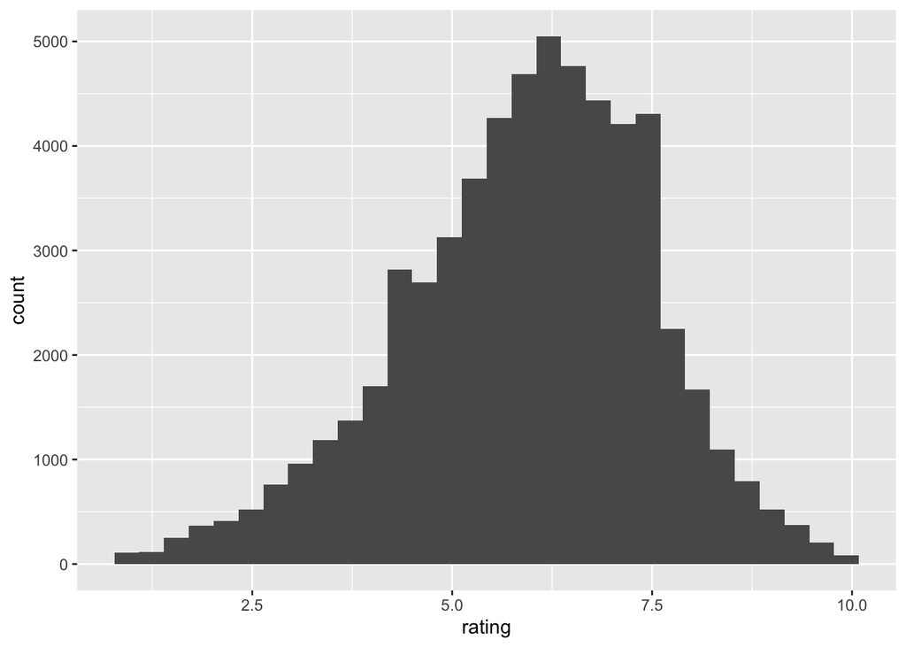

```r
h1<- ggplot(movies,aes(x=rating))+geom_histogram()
h1
```

## 3. Follwing the last question, change the histogram in green colour with the outline and fill out with grey colour

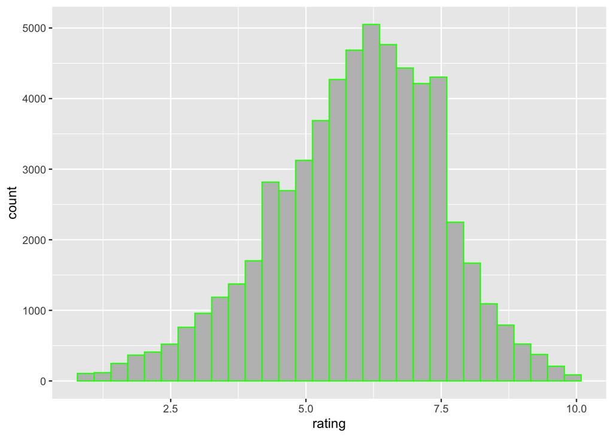

```r
h2<- h1+geom_histogram(color="green", fill="grey")
h2
```

## 4. Bar: display a bar of distribution of MPAA

```r
library(tidyverse)
```

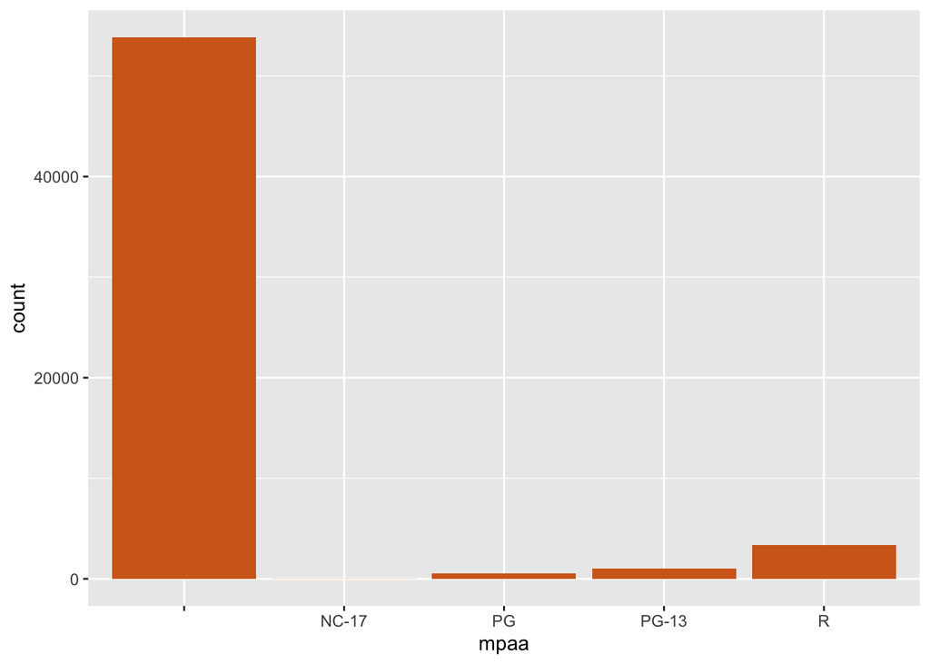

```r
movies1<-drop_na(movies, mpaa)
b1 <- ggplot(movies1,aes(x = mpaa)) + geom_bar(fill="chocolate")
b1
```

## Difference between BAR and HISTOGRAM:

- The Histogram refers to a graphical representation that shows data by way of bars to display the frequency of numerical data whereas the Bar graph is a graphical representation of data that uses bars to compare different categories of data.
- Histogram used for distribution of non-discrete variables while Bar Graph is used for comparison of discrete variables .
- In Histogram, we cannot rearrange the blocks while in Bar Charts, it is common to rearrange the blocks, from highest to lowest.
- Histogram used for displaying the frequency of occurrences and Bar Plots helps you to compare different categories of data. https://www.guru99.com/histogram-vs-bar-chart.html

## 5. Draw a scatterplot to describe the relationship between rating and the length of the movies(x is the length, y is the rating)

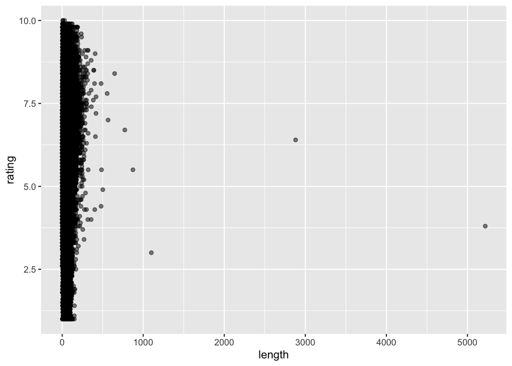

```r
s1<- ggplot(movies,aes(x=length, y=rating))+geom_point(alpha=.5)
s1
```

## 6. Ah…looks not so clear…so…zooming the x achsel and, btw, change a color make it beautiful (by a third variable ,here we use variable “year”)

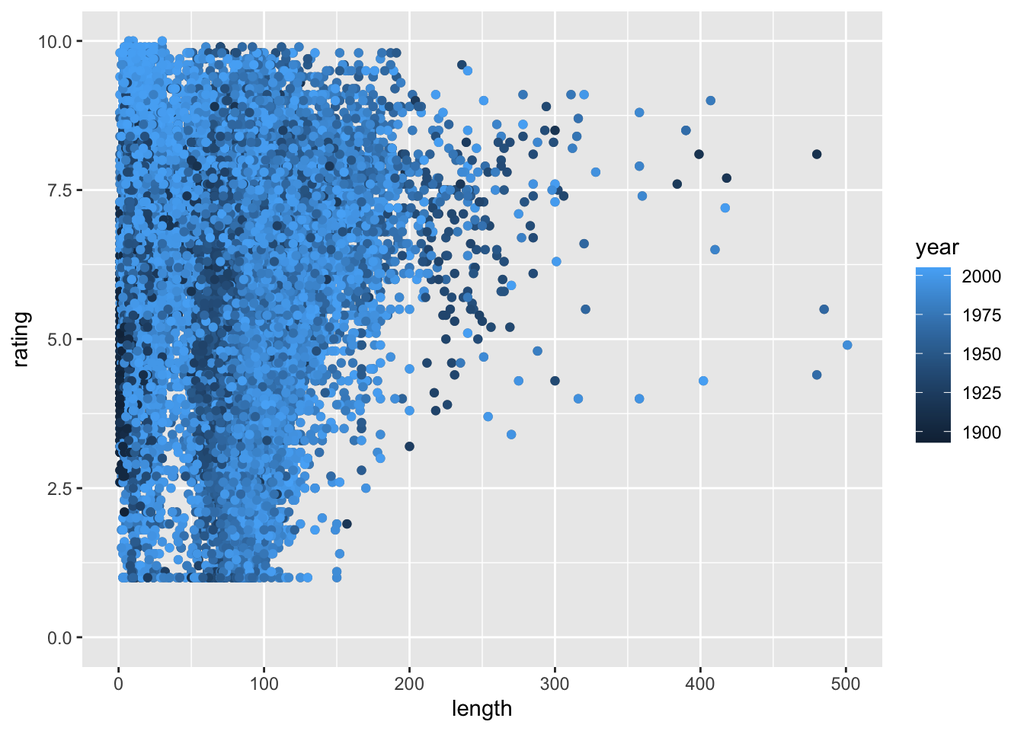

```r
s2<-s1+coord_cartesian(xlim = c(0,500),ylim = c(0,10))+geom_point(aes(color=year))
s2
```

Conclude: the length of movies does not affect the rating….

## 7. Lets change a new dataset: “mtcars” from ggplot2.

```r
glimpse(mtcars)
```

```
## Rows: 32
## Columns: 11
## $ mpg  <dbl> 21.0, 21.0, 22.8, 21.4, 18.7, 18.1, 14.3, 24.4, 22.8, 19.2, 17.8,…
## $ cyl  <dbl> 6, 6, 4, 6, 8, 6, 8, 4, 4, 6, 6, 8, 8, 8, 8, 8, 8, 4, 4, 4, 4, 8,…
## $ disp <dbl> 160.0, 160.0, 108.0, 258.0, 360.0, 225.0, 360.0, 146.7, 140.8, 16…
## $ hp   <dbl> 110, 110, 93, 110, 175, 105, 245, 62, 95, 123, 123, 180, 180, 180…
## $ drat <dbl> 3.90, 3.90, 3.85, 3.08, 3.15, 2.76, 3.21, 3.69, 3.92, 3.92, 3.92,…
## $ wt   <dbl> 2.620, 2.875, 2.320, 3.215, 3.440, 3.460, 3.570, 3.190, 3.150, 3.…
## $ qsec <dbl> 16.46, 17.02, 18.61, 19.44, 17.02, 20.22, 15.84, 20.00, 22.90, 18…
## $ vs   <dbl> 0, 0, 1, 1, 0, 1, 0, 1, 1, 1, 1, 0, 0, 0, 0, 0, 0, 1, 1, 1, 1, 0,…
## $ am   <dbl> 1, 1, 1, 0, 0, 0, 0, 0, 0, 0, 0, 0, 0, 0, 0, 0, 0, 1, 1, 1, 0, 0,…
## $ gear <dbl> 4, 4, 4, 3, 3, 3, 3, 4, 4, 4, 4, 3, 3, 3, 3, 3, 3, 4, 4, 4, 3, 3,…
## $ carb <dbl> 4, 4, 1, 1, 2, 1, 4, 2, 2, 4, 4, 3, 3, 3, 4, 4, 4, 1, 2, 1, 1, 2,…
```

dataset description:

[, 1] mpg: Miles/(US) gallon

[, 2] cyl: Number of cylinders

[, 3] disp: Displacement (cu.in.)

[, 4] hp: Gross horsepower

[, 5] drat: Rear axle ratio

[, 6] wt: Weight (1000 lbs)

[, 7] qsec: 1/4 mile time

[, 8] vs: Engine (0 = V-shaped, 1 = straight)

[, 9] am: Transmission (0 = automatic, 1 = manual)

[,10] gear: Number of forward gears

https://www.rdocumentation.org/packages/datasets/versions/3.6.2/topics/mtcars

## 8. Draw a scatterplot to find out the relationship between mpg and hp

https://rstudio-pubs-static.s3.amazonaws.com/234758_336c814abe0040538c44ddf0426565b0.html

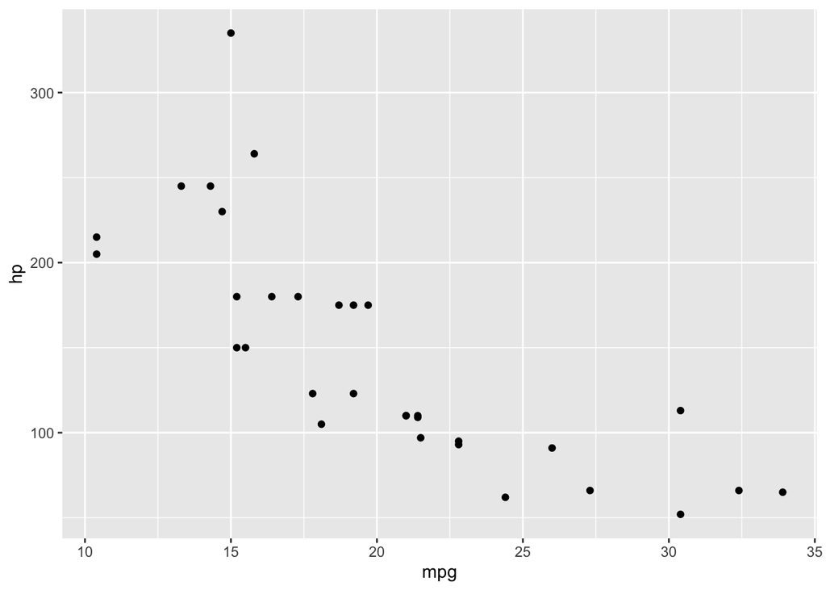

```r
mtcars1<-ggplot(data=mtcars,aes(x=mpg,y=hp))+geom_point()
mtcars1
```

## 9. Following the last question, just make it looked dynamic, so let us change the shape, color and size

https://rstudio-pubs-static.s3.amazonaws.com/234758_336c814abe0040538c44ddf0426565b0.html

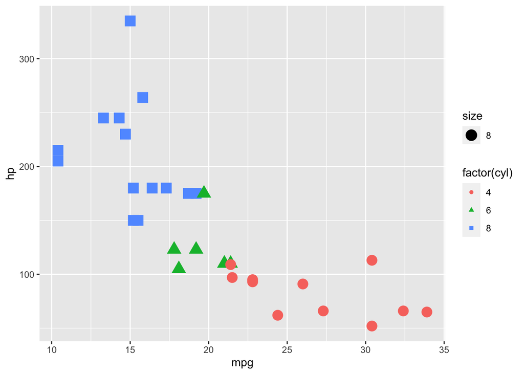

```r
# change the color and shape based on the third variable, here is"cyl".
# if we want to show groups(discrete) of cyl, we're safest bet is to convert to factor, that is factor(cyl). if we wnat to show a constant change of color, than dont need factor()

mtcars2<-mtcars1+geom_point(aes(shape=factor(cyl),color=factor(cyl),size=8))
mtcars2
```

## 10.Display different enigine(vs)’s relastionship of mpg and hp, using facet_wrap

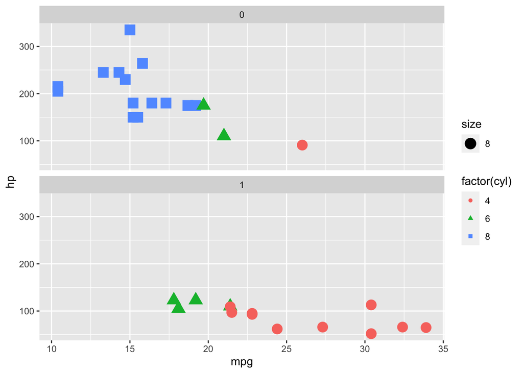

```r
mtcars3 <-mtcars2+facet_wrap(~ vs, nrow = 2)
mtcars3
```

## 11. Following the last questions, add a trend line

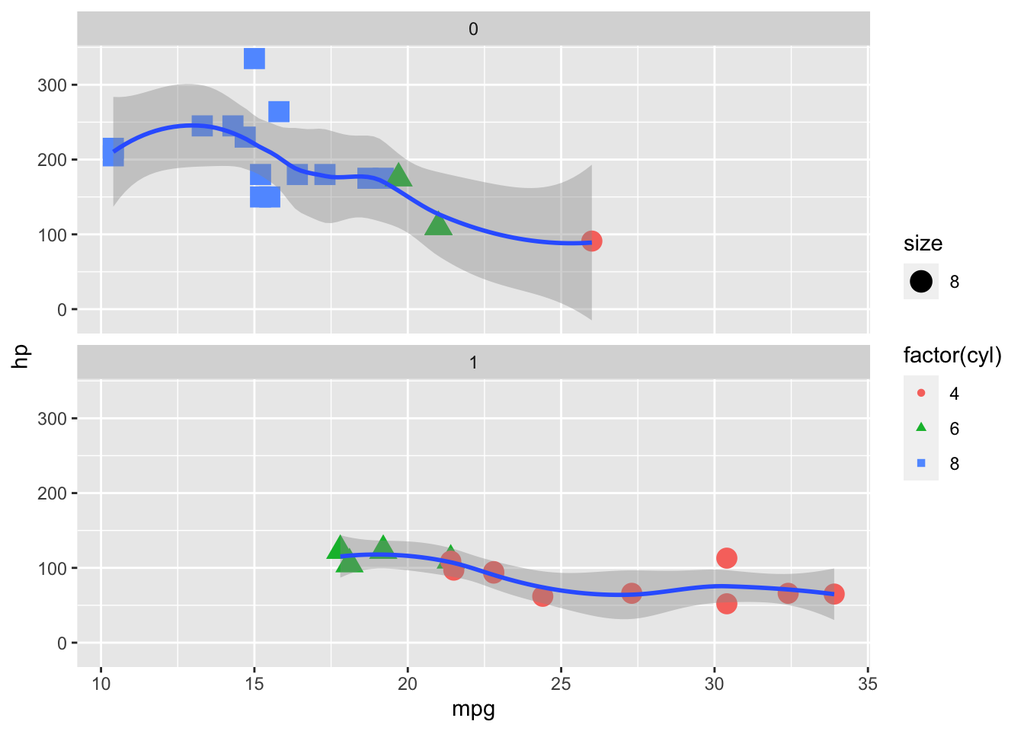

```r
mtcars4 <-mtcars3+stat_smooth()
mtcars4
```

## 12. Summarize data and show in the plot (group_by(), summarise() will be official introduced in next step)

https://data-se.netlify.app/2020/12/07/ex-visualizing-diamonds/

```r
mtcars %>%
  group_by(vs) %>%
  summarise(mpg_md_vs = median(mpg, na.rm = T),
            mpg_max_vs = max(mpg, na.rm = T)) -> mtcars_summarized

mtcars_summarized
```

```
## # A tibble: 2 x 3
##      vs mpg_md_vs mpg_max_vs
##   <dbl>     <dbl>      <dbl>
## 1     0      15.6       26
## 2     1      22.8       33.9
```

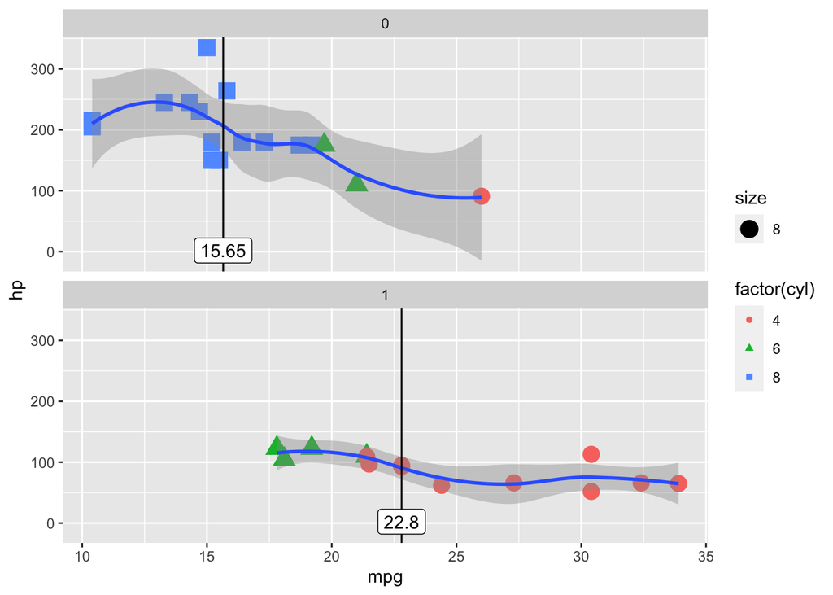

```r
mtcars5 <- mtcars4 +
  geom_vline(data = mtcars_summarized, aes(xintercept = mpg_md_vs)) +
  geom_label(data = mtcars_summarized, aes(x = mpg_md_vs,
                                             y = mpg_max_vs*0.07, # at 7% height
                                             label = mpg_md_vs))


mtcars5
```